# Reproducible Research: Peer Assessment 1

This is markdown document addressing peer assigment 1 from “Reproducilbe Research”

## Loading and preprocessing the data

Lets read data from the zip file

```r
dataDF<-read.csv(unz("repdata_data_activity.zip","activity.csv"), na.strings = c("","NA"))
dataDF$date<-as.Date(dataDF$date)
```

## What is mean total number of steps taken per day?

Time to calculate total number of steps taken each day

```
##          date steps
## 1  2012-10-02   126
## 2  2012-10-03 11352
## 3  2012-10-04 12116
## 4  2012-10-05 13294
## 5  2012-10-06 15420
## 6  2012-10-07 11015
## 7  2012-10-09 12811
## 8  2012-10-10  9900
## 9  2012-10-11 10304
## 10 2012-10-12 17382
## 11 2012-10-13 12426
## 12 2012-10-14 15098
## 13 2012-10-15 10139
## 14 2012-10-16 15084
```

[output cut: 39 more lines]

Now, let’s plot histogram of total steps by day

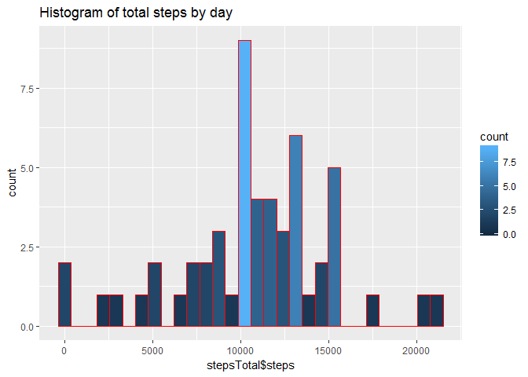

Mean of the total number of steps taken per day:

```
## [1] 10766.19
```

Median of the total number of steps taken per day:

```
## [1] 10765
```

## What is the average daily activity pattern?

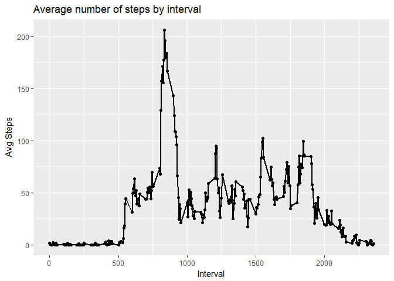

Which 5-minute interval, on avarage across all the days in the dataset, contains the maximum number of steps?

```
## [1] 835
```

## Imputing missing values

Time to handle missing values (if I can ;) ) Calculating the total number of missing values in the dataset

```r
sum(is.na(dataDF$steps))
```

```
## [1] 2304
```

The strategy for filling in all the missing values in the dataset. Super simple approach - I take average number of steps for the interval. “stepsAvg” holds number of steps by interval.

```
##     interval          steps
##  Min.   :   0.0   Min.   :  0.000
##  1st Qu.: 588.8   1st Qu.:  2.486
##  Median :1177.5   Median : 34.113
##  Mean   :1177.5   Mean   : 37.383
##  3rd Qu.:1766.2   3rd Qu.: 52.835
##  Max.   :2355.0   Max.   :206.170
```

A new dataset is created like this:

```r
library(plyr)
names(stepsAvg)[2]<-"stepsmean"
dataDFFixed<-join(dataDF,stepsAvg,by="interval",type="inner")
dataDFFixed$steps<-ifelse(is.na(dataDFFixed$steps),as.integer(dataDFFixed$stepsmean), dataDFFixed$steps)
dataDFFixed<-dataDFFixed[,1:3]
```

The dataset has been fixed, we will plot histogram now:

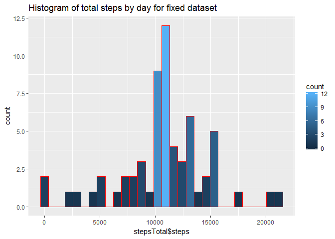

Mean of the total number of steps taken per day for fixed dataset:

```
## [1] 10749.77
```

Median of the total number of steps taken per day for fixed dataset:

```
## [1] 10641
```

## Are there differences in activity patterns between weekdays and weekends?

We are going to create a new dataset that will have weekday factor.

```r
dataDFFixed$weekpart<-ifelse(weekdays(dataDFFixed$date) %in% c("Saturday","Sunday"), "weekend", "weekday")
```

Panel plot with time series plots of the 5-minute interval and the average steps taken, averaged across all weekday days or weekend days

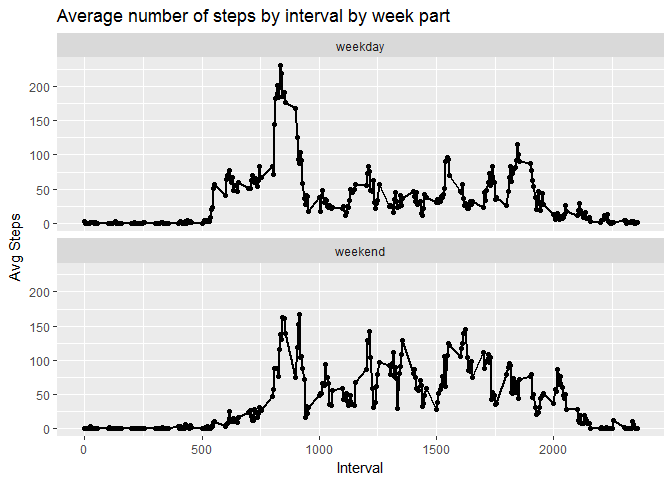

[output not shown]